# Machine-Learning-vol.09-性能評価とチューニング

## 9.1 分類問題の性能指標

本章のテーマは､**性能評価とチューニング**です｡前回の**SVM**で､**ハイパーパラメータを何かしらの｢ちょうどいい値｣に定めることが必要になりました**｡今回は､その**｢ちょうどいい値｣**を自動的に見つけるための**グリッドサーチ**という手法について学びます｡ハイパーパラメータの値の様々な組み合わせに対して学習を行い､**最適な組み合わせを探索的に見つけます**｡また､そのための前提知識となる**分類問題の性能指標**や､**より信頼性の高い汎化性能の評価方法**を学びます｡

[figure not shown]

汎化性能を評価するにあたって､**まずはその評価指標を正しく理解する必要があります**｡特に､**分類問題には回帰問題以上に多様な評価指標があります**｡そのため､**｢その性能指標が高い数値になればなるほど､自分の目的はよく達成される｣**と言えるような指標を慎重に選ぶ必要が出てきます｡これができなければ､**汎化性能を本来のものよりも高く見積もりすぎてしまう危険があります**｡

### 9.1.1 混同行列（2クラス分類の場合）

混同行列とは､**モデルの間違いの傾向を知るための行列です**｡まずは2クラス分類における､**陽性**と**陰性**を分類することを考えます｡縦軸に正解ラベル､横軸に予測ラベルをとることで､**陽性を陰性と間違えやすいのか､陰性を陽性と間違えやすいのかなどの傾向がわかります**｡分類問題の性能指標は､**この混同行列をもとに作られるので**非常に重要な概念です｡

[figure not shown]

#### 分類問題をSVCで解く

**混同行列**を出力するにあたって､例題として前章と同じ**irisデータのSVMによる分類**を行います｡

```python
# 必要なライブラリを読込
import numpy as np
import pandas as pd
import matplotlib.pyplot as plt
% matplotlib inline
```

```python
# versicolorとversinicaの二値分類をする
from sklearn.datasets import load_iris

iris = load_iris()
X_1 = iris.data[50:, [0, 2]]
y_1 = iris.target[50:]

# データセットの分割
from sklearn.model_selection import train_test_split
X_1_train, X_1_test, y_1_train, y_1_test = train_test_split(X_1, y_1, test_size=0.3, random_state=0)

# 線形SVCの学習
from sklearn.svm import SVC
svc_1 = SVC(kernel='linear', C=1.0)
svc_1.fit(X_1_train, y_1_train)
```

```
SVC(C=1.0, cache_size=200, class_weight=None, coef0=0.0,
  decision_function_shape=None, degree=3, gamma='auto', kernel='linear',
  max_iter=-1, probability=False, random_state=None, shrinking=True,
  tol=0.001, verbose=False)
```

#### 混同行列を出力

混同行列は､**sklearn.metrics**の**confusion_matrix**を利用して出力できます｡また､このとき**必ずtestデータを利用すること**に注意してください｡

```python
# 混合行列のarrayを作成
# (正解ラベル, 予測ラベル)
from sklearn.metrics import confusion_matrix
cm_1 = confusion_matrix(y_1_test, svc_1.predict(X_1_test))
cm_1
```

```
array([[13,  2],
       [ 1, 14]])
```

また､**より直感的に捉えやすくするため**､グラフで出力することもできます｡

```python
# 混合行列をグラフでプロットする関数
def plot_cm(confmat):
    fig, ax = plt.subplots(figsize=(5, 5))
    ax.matshow(confmat, cmap=plt.cm.Blues, alpha=0.3)
    for i in range(confmat.shape[0]):
        for j in range(confmat.shape[1]):
            ax.text(x=j, y=i, s=confmat[i, j], va='center', ha='center')
    plt.title('predicted label')
    plt.ylabel('true label')
    plt.tight_layout() # ラベルが重ならないように自動調整
    plt.show()
```

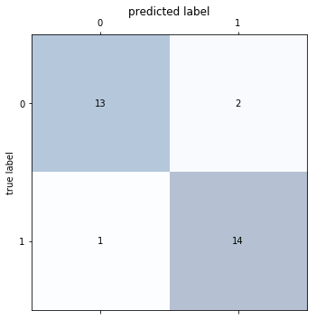

```python
# 混同行列をグラフでプロット
plot_cm(cm_1)
```

この混同行列をもとに算出される**分類問題の性能指標**を紹介します｡まずは､**こちらも2クラス分類を前提にします**｡多クラス分類への拡張は､次節で紹介します｡

### 9.1.2 正答率（Accuracy）

正答率とは､**｢全体のうち､どれだけの割合で正解できたか｣**を表す指標です｡正答率は初学者にも馴染みのある指標であり､分類モデルの**score**メソッドで出力していたのも正答率です｡

[figure not shown]

```python
# 正答率を出力
from sklearn import metrics
metrics.accuracy_score(y_1_test, svc_1.predict(X_1_test))
```

```
0.90000000000000002
```

#### コラム : 正答率 99%の分類器は優秀か？

機械学習のモデルに得意不得意があるように､**性能指標にも得意不得意があり､ケースに応じた選択をする必要があります**｡実は､今まで当たり前のように使ってきた**正答率**にも弱点があり､**サンプル数の少ないクラスを軽視してしまっても､ある程度の高い数値が得られてしまいます**｡

極端な例を挙げると､**医療現場における疾病判定**をするときに､**100人中1人しか罹らない病気の判定に関して､全員に｢健康です｣と診断する分類器をつくれば､正答率は99%になります**｡しかし､病気に罹っている一人を見つけ出せないのでは､分類器をつくった意味がありません｡なのであれば､このモデルをつくるときに､**正答率が高いだけのモデルをつくろうとしても本質的には意味がないのです**｡

[figure not shown]

### 9.1.3 再現率（recall）

**再現率（別名: 感度､ヒット率､真陽性率）**は､**｢陽性であるサンプルを､いかに見抜けたか｣**を表す指標です｡定義式の構造上､**偽陰性が少なくなるほど高くなるようになっています**｡偽陰性とは､**本当は陽性だけど陰性だと予測してしまったtestサンプルの数**なので､**｢少しでも陽性の可能性があるものは､念のため陽性にしておこう｣**という考え方をすると､再現率は高くなることになります｡

[figure not shown]

利用されるケースとしては､**医療現場における疾病の判定**などが挙げられます｡たとえば､癌にかかっているかどうかを予測するようなケースです｡この場合は､偽陽性が出てしまっても精密検査の費用が無駄になるだけですが､**偽陰性が出てしまうとその患者の早期発見が遅れてしまい､取り返しがつかないほど癌が進行してしまうことになりかねません**｡そのため､偽陰性を少なくすることに焦点を当てる再現率の利用が好ましいのです｡

[figure not shown]

```python
# 再現率を出力
metrics.recall_score(y_1_test, svc_1.predict(X_1_test))
```

```
0.8666666666666667
```

### 9.1.4 適合率（precision）

**適合率（別名:陽性的中率）**は､**｢モデルによる陽性判定が､どの程度信頼できるか｣**を表す指標です｡定義式の構造上､**偽陽性が少なくなるほど高くなるようになっています**｡偽陽性とは､**本当は陰性だけど陽性だと予測してしまったtestサンプルの数**なので､**｢確実に陽性だと思えるものしか､陽性と判定しない｣**という考え方をすると､適合率は高くなることになります｡

[figure not shown]

利用されるケースとしては､**検索エンジンによるWebページの選別**などが挙げられます｡ユーザーが検索ワードを指定して､それに関連するWebページが陽性だとします｡このとき､**ユーザーは自分が欲しかった情報が載っていない､陰性のページばかりが並んでいるとイライラします**｡つまりは､**陰性がどれだけ混ざり込んでいないか**といことが重視されるのです｡そのため､偽陽性を少なくすることに焦点を当てる適合率の利用が好ましいのです｡

[figure not shown]

```python
# 適合率を出力
metrics.precision_score(y_1_test, svc_1.predict(X_1_test))
```

```
0.9285714285714286
```

### 9.1.5 F値（F-measure）

F値とは､**適合率と再現率の調和平均**です｡前提として､**適合率と再現率はトレードオフの関係にあります**｡たとえば､ほとんど全てのサンプルを陽性と判定してしまえば､偽陰性が出にくくなって**再現率**が大きくなります｡逆に､ほとんど全てのサンプルを陰性と判定してしまえば､偽陽性が出にくくなって**適合率**が大きくなります｡そこで､**両者のバランスをとることを目指したものがF値**です｡

[figure not shown]

```python
# F値を出力
metrics.f1_score(y_1_test, svc_1.predict(X_1_test))
```

```
0.89655172413793105
```

### 9.1.6 混同行列（多クラス分類の場合）

多クラス分類の場合の混同行列も､**正解のクラスラベルと予測したクラスラベルの対応だけを考えれば同様に定義できます**｡このとき気をつけるべきは､ **$TP, FP, TN, FN$ のとり方**です｡多クラス分類におけるこれらは､それぞれのクラスラベルに対して**一対他の2値分類**を考えることで定義できます｡つまりは､クラス0に関して $TP_0, FP_0, TN_0, FN_0$ が､クラス1に関して $TP_1, FP_1, TN_1, FN_1$ が考えられるということです｡

[figure not shown]

```python
# 3クラス分類を実行する
iris = load_iris()
X_2 = iris.data[:, [0, 2]]
y_2 = iris.target

# データセットの分割
X_2_train, X_2_test, y_2_train, y_2_test = train_test_split(X_2, y_2, test_size=0.3, random_state=0)

# 線形SVCの学習
from sklearn.svm import SVC
svc_2 = SVC(kernel='linear', C=1.0)
svc_2.fit(X_2_train, y_2_train)
```

```
SVC(C=1.0, cache_size=200, class_weight=None, coef0=0.0,
  decision_function_shape=None, degree=3, gamma='auto', kernel='linear',
  max_iter=-1, probability=False, random_state=None, shrinking=True,
  tol=0.001, verbose=False)
```

```python
# 混合行列の作成
# arrayで出力
cm_2 = confusion_matrix(y_2_test, svc_2.predict(X_2_test))
cm_2
```

```
array([[16,  0,  0],
       [ 0, 17,  1],
       [ 0,  1, 10]])
```

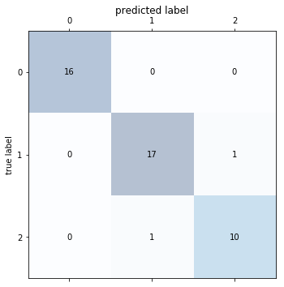

```python
# 混同行列をグラフでプロット
# 色の濃いところほどサンプルが集中している
plot_cm(cm_2)
```

多クラス分類の場合の性能指標は､各クラスについて考えた一対他の2値分類の $TP_j, FP_j, TN_j, FN_j$ を利用します｡算出には､**ミクロ平均**と**マクロ平均**という計算手法を用います｡両者の違いは､**クラスごとのサンプル数の偏りを調整するかしないか**です｡**調整しないときはミクロ平均を､調整するときはマクロ平均を利用します**｡サンプル数が多いクラスを重視すするのか､全てのクラスを平等に扱うのかによって使い分けることができます｡

### 9.1.7 ミクロ平均

ミクロ平均とは､**クラスごとのサンプル数の偏りを調整しない場合の平均の取り方**です｡たとえば､$TP$ を利用しているところを $TP_0 + ... + TP_n$ に置き換えて計算します｡たとえば､**適合率**のミクロ平均は以下のような計算式になります｡

$$PRE_{micro} = \frac{TP_0 + ... + TP_n}{(TP_0 + FP_0)+ ... + (TP_n + FP_n)}$$

### 9.1.8 マクロ平均

マクロ平均とは､**サンプル数の偏りを調整する場合の平均の取り方**です｡各クラスごとに一対他の2値分類を考え､各クラスごとの $TP_j, FP_j, TN_j, FN_j$ を求めるところまではミクロ平均と同じですが､マクロ平均では**各クラスのごとに個別に評価指標を求めてしまい､その後で性能指標の平均を取ります**｡たとえば､**適合率**のマクロ平均は以下のような式になります｡

$$PRE_{macro} = \frac{PRE_0 +...+ PRE_n}{n}$$

なぜ､マクロ平均のような計算の工夫がされるのかというと､ミクロ平均では､**サンプル数の少ないクラスが軽視されてしまうため**です｡クラスごとのサンプル数におおきな偏りがあったとき､ミクロ平均で考えてしまうと､**サンプル数が多いクラスに対してさえ上手く予測できていれば､少ないクラスに対して外してしまってもさほど影響がない**という状態になってしまいます｡しかし､マクロ平均のこのように先に評価指標を計算すれば､**サンプルごとの個数の偏りが性能指標の計算のときに吸収されて､平均の数値に影響しにくくなります**｡

[figure not shown]

以上のことを踏まえて､ミクロ平均とマクロ平均を使い分ける必要があります｡**多数派のクラスを重視したいときはミクロ平均**を､**全体を均等に評価したいときはマクロ平均**を利用するのがよいでしょう｡

```python
# 適合率のマクロ平均
metrics.precision_score(y_2_test, svc_2.predict(X_2_test), average='macro')
```

```
0.95117845117845112
```

```python
# 再現率のマクロ平均
metrics.recall_score(y_2_test, svc_2.predict(X_2_test), average='macro')
```

```
0.95117845117845112
```

```python
# F値のマクロ平均を出力
# averageの指定必須
metrics.f1_score(y_2_test, svc_2.predict(X_2_test), average='macro')
```

```
0.95117845117845112
```

## 9.2 交差検証法

交差検証法（Cross_Validation）とは､**アルゴリズムが実現するであろう汎化性能を信頼性高く見積もる手法**です｡**学習データをk個に分割して､うち1つを検証用､残りを学習用にしてホールド・アウト法の学習を行い､それをk回繰り返します**｡そして､k回の学習のそれぞれでtest精度を求めた後にそれらの平均を取り､モデルの実現しうるtest精度とします｡このことから､交差検証は**k分割交差検証法（k-fold Cross-Validation）**とも呼ばれています｡通常のホールド・アウト法よりも信頼性の高い評価ができることが利点です｡

[figure not shown]

### 9.2.1 ホールド・アウト法の問題点

これまで利用してきたホールド・アウト法には､**検証データの選び方によってtest精度が大きくばらついてしまう可能性が高い**という欠点があります｡たとえば､分割の際にたまたま予測がしにくいデータばかりがtestデータに割り当てられてしまうと､test精度は本来あるべき値より低く見積もられます｡逆に､余計に高く見積もられることもあります｡特に､**規模の小さいデータほどその可能性が高くなります**｡しかし､交差検証法を利用するとtestデータを取り替えた場合のそれぞれについて平均をとるので､こうした偶然によるばらつきを吸収することができます｡

[figure not shown]

### 9.2.2 Bostonデータを用いた実装

まずは､この交差検証を**Bostonデータ**を題材に実装してみます｡3章の重回帰分析のときと全く同じ状況で､ホールド・アウト法と交差検証法を比較します｡今回は回帰分析なので､出力される性能指標は決定係数です｡

```python
# データセットの読み込み
from sklearn.datasets import load_boston
boston = load_boston()

# DataFrameを生成
df_data = pd.DataFrame(boston.data, columns=boston.feature_names)
df_target = pd.DataFrame(boston.target, columns=['MEDV'])
df = pd.concat([df_data, df_target], axis=1)
df.head()
```

|  | CRIM | ZN | INDUS | CHAS | NOX | RM | AGE | DIS | RAD | TAX | PTRATIO | B | LSTAT | MEDV |
| --- | --- | --- | --- | --- | --- | --- | --- | --- | --- | --- | --- | --- | --- | --- |
| 0 | 0.00632 | 18.0 | 2.31 | 0.0 | 0.538 | 6.575 | 65.2 | 4.0900 | 1.0 | 296.0 | 15.3 | 396.90 | 4.98 | 24.0 |
| 1 | 0.02731 | 0.0 | 7.07 | 0.0 | 0.469 | 6.421 | 78.9 | 4.9671 | 2.0 | 242.0 | 17.8 | 396.90 | 9.14 | 21.6 |
| 2 | 0.02729 | 0.0 | 7.07 | 0.0 | 0.469 | 7.185 | 61.1 | 4.9671 | 2.0 | 242.0 | 17.8 | 392.83 | 4.03 | 34.7 |
| 3 | 0.03237 | 0.0 | 2.18 | 0.0 | 0.458 | 6.998 | 45.8 | 6.0622 | 3.0 | 222.0 | 18.7 | 394.63 | 2.94 | 33.4 |
| 4 | 0.06905 | 0.0 | 2.18 | 0.0 | 0.458 | 7.147 | 54.2 | 6.0622 | 3.0 | 222.0 | 18.7 | 396.90 | 5.33 | 36.2 |

```python
# 変数を格納
# 説明変数: LSTAT, RM
X_3 = df.loc[:, ['LSTAT', 'RM']].values
y_3 = df.loc[:, ['MEDV']].values
```

```python
# 線形回帰のインスタンスを生成
from sklearn.linear_model import LinearRegression
lr = LinearRegression()
```

#### KFold

データの分割方法の指定を､**sklearn.model_selection**の**KFold**を利用して実行できます｡各引数の意味合いは以下の通りです｡

- n_splits: データを分割する個数k｡通常5〜10個程度｡小さいデータほど数多く分割する必要がある｡
- shuffle: 分割を行う前にデータをシャッフルするかどうか｡Trueにしておいた方が信頼性が上がる｡
- random_state: 乱数生成器の状態｡これを固定しておけば､毎回同じ分割結果が得られる｡

```python
# データの分割方法を指定
from sklearn.model_selection import KFold
kf_3 = KFold(n_splits=5, shuffle=True, random_state=0)
```

#### cross_val_score

次に､KFoldで指定した分割方法でデータを分割し､k回の学習のそれぞれについてtest精度を求めます｡この処理は同じく**sklearn.model_selection**の**cross_val_score**を用いて実行できます｡このとき注意すべきことは､**cross_val_scoreは学習済みモデルのインスタンスを提供していない**ということです｡あくまで､**｢このアルゴリズムで学習をさせた場合､どれだけの汎化性能が見込めるか｣**ということを知らせてくれるだけに過ぎません｡

```python
# 交差検証を実行
# (モデル, 説明変数, 目的変数, 分割の方法)
from sklearn.model_selection import cross_val_score
scores_3 = cross_val_score(lr, X_3, y_3, cv=kf_3)
scores_3
```

```
array([ 0.54090848,  0.70922084,  0.57458547,  0.55307476,  0.738459  ])
```

汎化性能の評価は､返されたk個のtest精度の**平均値**を参考に行います｡

```python
# 交差検証精度の平均を出力
scores_3.mean()
```

```
0.62324971110773009
```

また､標準偏差を出力すれば､**testデータのとり方を変えるだけでtest精度がどれだけばらつくのか**を知ることができます｡

```python
# 交差検証精度の標準偏差を出力
scores_3.std()
```

```
0.083351095185182217
```

### 9.2.3 層化交差検証法

層化交差検証法とは､**分類問題に適した交差検証の方法**です｡通常､データの分割は**完全にランダム**に行われるのですが､そこに**｢クラスラベルを等分する｣**という条件を追加します｡こうすることで､**k個の組の選び方によらず各クラスラベルに対する精度を求めるとこができます**｡**回帰のときは通常の交差検証､分類のときは層化交差検証**という使い分けが推奨されます｡

[figure not shown]

```python
# irisデータセットの読み込み
# 変数: petal length, petal width
from sklearn.datasets import load_iris
iris = load_iris()
X_4 = iris.data[:,[2,3]]
y_4 = iris.target
```

```python
# SVMのインスタンスを生成
from sklearn.svm import SVC
svc_4 = SVC(kernel='rbf', gamma=0.1, C=1.0)
```

#### StratifiedKFold

層化を行う場合には､**KFold**ではなく**StratifiedKFold**クラスを利用します｡引数の指定はKFoldと同様です｡

```python
# データの分割方法を指定（層化）
from sklearn.model_selection import StratifiedKFold
kf_4 = StratifiedKFold(n_splits=5, shuffle=True, random_state=0)
```

```python
from sklearn.model_selection import cross_val_score
scores_4 = cross_val_score(svc_4, X_4, y_4, cv=kf_4)
```

```python
# 交差検証精度の平均を出力
scores_4.mean()
```

```
0.96666666666666679
```

```python
# 交差検証精度の標準偏差を出力
scores_4.std()
```

```
0.029814239699997188
```

## 9.3 グリッドサーチ

グリッドサーチとは､**ハイパーパラメータのちょうどいい値を探索的に定める手法**です｡その名の通り**格子点（Grid）**の上を**探索（Search）**するようにしらみ潰しにハイパーパラメータの組み合わせを試して､**汎化性能が最も高くなるような組み合わせを探します**｡たとえば､前章で扱った**カーネルSVM**であれば､ちょうどいい $C$ と $\gamma$ の組み合わせを見つけることを目指します｡また､今回はこのグリッドサーチをscikit-learnの**GridSearchCVクラス**を用いて行います｡こちらは､グリッドサーチを交差検証法を用いて行うクラスです｡

[figure not shown]

### 9.3.1 前処理

今回も､前章と同じXORのデータを利用します｡

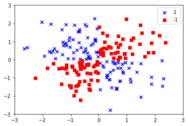

```python
# XORのデータの作成
np.random.seed(0)
X_xor = np.random.randn(200, 2)
y_xor = np.logical_xor(X_xor[:, 0] > 0, X_xor[:, 1] > 0)
y_xor = np.where(y_xor, 1, -1)

# データのプロット
plt.scatter(X_xor[y_xor == 1, 0], X_xor[y_xor == 1, 1], c='b', marker='x', label='1')
plt.scatter(X_xor[y_xor == -1, 0], X_xor[y_xor == -1, 1], c='r', marker='s', label='-1')
plt.xlim([-3, 3])
plt.ylim([-3, 3])
plt.legend(loc='best') # 右上に凡例を出力
plt.show()
```

#### ホールド・アウト法による分割

グリッドサーチの場合は､**あらかじめホールド・アウト法による分割が必要になります**｡trainデータとtestデータの分割を行い､**trainデータだけを用いてグリッドサーチを行います**｡なぜかというと､testデータを含めてハイパーパラメータの組み合わせの選定をしてしまうと､**testデータに都合よく適合するパラメータが選ばれてしまうからです**｡**testデータは将来的に得られるデータを想定しているため､モデルにとって完全に初めて見るデータになっていなければ意味がありません**｡なので､ハイパーパラメータの調整にも利用してはいけないのです｡また､このようにtestデータの情報がモデルに漏れ出すなどして､**運用の際に利用できない情報がモデルに与えられてしまうこと**を**leakage**といいます｡

[figure not shown]

```python
# ホールド・アウト法による分割
X_xor_train, X_xor_test, y_xor_train, y_xor_test = train_test_split(X_xor, y_xor, test_size=0.3, random_state=0)
```

#### 調整候補のパラメータを指定

調整すべきパラメータのそれぞれについて､**候補となる値を指定します**｡これらの候補によってGridが作られます｡

```python
# 調整したいパラメータを指定
param_grid = {'C': [0.1, 1.0, 10, 100, 1000, 10000],
              'gamma': [0.001, 0.01, 0.1, 1, 10]}
```

```python
# データの分割方法を指定（層化）
from sklearn.model_selection import StratifiedKFold
kf_5 = StratifiedKFold(n_splits=5, shuffle=True, random_state=0)
```

**GridSearchCV**クラスは､**sklear.model_selection**に収録されています｡

```python
# GridSearchCVのインスタンスを生成
from sklearn.model_selection import GridSearchCV
from sklearn.svm import SVC
# (モデルのインスタンス, 試したいパラメータの値, 分割方法)
gs_svc = GridSearchCV(SVC(), param_grid, cv=kf_5)
```

### 9.3.2 GridSearchCVの学習

GridSearchCVは､その名の通り**交差検証を用いたグリッドサーチを実行してくれるクラス**です｡また､以下のフローを一気通貫で行ってくれるため､非常に便利です｡多くの場合､交差検証という単語は､こちらのGridSearchCVを指して言われます｡

1. 指定のハイパーパラメータの組み合わせのすべてについて交差検証を行う
2. すべての組み合わせについて交差検証の平均値を比較する
3. **最もtest精度が高かったパラメータを用いてインスタンスを生成する**
4. **引き渡されたインスタンスを学習させる**
5. 以後､**学習済みのインスタンスと同様に振る舞う**

#### 計算量の課題

GridSearchCVは**計算時間がかかりやすい**という課題を抱えています｡たとえば､ $\gamma$ を5通り､ $C$ を5通り指定して､交差検証を10分割で行うとすれば､単純に5×5×10=250回の学習が必要になります｡その場合は学習時間も単純に通常の250倍かかります｡**データが大規模になったり､モデルが複雑になったりするほどこのデメリットは深刻になります**｡

```python
# GridSearchCVを利用した学習
# 最適なパラメータを自動で採用した分類器となる
gs_svc.fit(X_xor_train, y_xor_train)
```

```
GridSearchCV(cv=StratifiedKFold(n_splits=5, random_state=0, shuffle=True),
       error_score='raise',
       estimator=SVC(C=1.0, cache_size=200, class_weight=None, coef0=0.0,
  decision_function_shape=None, degree=3, gamma='auto', kernel='rbf',
  max_iter=-1, probability=False, random_state=None, shrinking=True,
  tol=0.001, verbose=False),
       fit_params={}, iid=True, n_jobs=1,
       param_grid={'C': [0.1, 1.0, 10, 100, 1000, 10000], 'gamma': [0.001, 0.01, 0.1, 1, 10]},
       pre_dispatch='2*n_jobs', refit=True, return_train_score=True,
       scoring=None, verbose=0)
```

### 9.3.3 最適なモデルの確認

#### 最適なハイパーパラメータの組み合わせを出力

すべてのハイパーパラメータの組み合わせの中で､**交差検証におけるtest精度平均が最も高かった最適解**を出力します｡このとき､**最適解が格子の内側にあることを確認してください**｡もし､最適解が格子の辺や隅にあった場合は､**格子の外によりよい本当の最適解が隠れている可能性があります**｡

[figure not shown]

```python
# test精度の平均が最も高かった組み合わせを出力
gs_svc.best_params_
```

```
{'C': 1000, 'gamma': 0.1}
```

また､**最適な組み合わせでの交差検証の平均精度が確認できます**｡選択したアルゴリズムでは､**ハイパーパラメータを最適に調整したときにこのくらいの汎化性能が見込め**るということを意味します｡

```python
# そのときのtest精度の平均を出力
gs_svc.best_score_
```

```
0.97142857142857142
```

実際の正答率を出力してみます｡

```python
# ホールド・アウト法によるtest精度を出力
gs_svc.score(X_xor_test, y_xor_test)
```

```
0.96666666666666667
```

決定境界を可視化してみます｡

```python
# ２次元データの決定曲線をプロットする関数
def plot_decision_regions(X, y, classifier, resolution=0.02):
    from matplotlib.colors import ListedColormap
    markers = ("s", "x", "o", "^", "v")
    colors = ("red", "blue", "lightgreen", "gray", "cyan")
    cmap = ListedColormap(colors[:len(np.unique(y))])

    x1_min, x1_max = X[:, 0].min()-1 , X[:, 0].max() +1
    x2_min, x2_max = X[:, 1].min()-1 , X[:, 1].max() +1

    xx1, xx2 = np.meshgrid(np.arange(x1_min, x1_max, resolution), np.arange(x2_min, x2_max, resolution))
    Z = classifier.predict(np.array([xx1.ravel(), xx2.ravel()]).T)
    Z = Z.reshape(xx1.shape)
    plt.contourf(xx1, xx2, Z, alpha=0.4, cmap=cmap)
    plt.xlim(xx1.min(), xx1.max())
    plt.ylim(xx2.min(), xx2.max())
    for idx, cl in enumerate(np.unique(y)):
        plt.scatter(x=X[y == cl, 0], y=X[y == cl, 1], alpha=0.8, c=cmap(idx),marker=markers[idx], label=cl)
    plt.show()
```

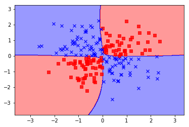

```python
# 決定境界の出力
plot_decision_regions(X_xor, y_xor, gs_svc)
```

[figure not shown]

監修: 東京女子大学情報処理センター 浅川伸一